# Final Project: Examining the Relationship Between Demographics, Admission Types, and Clinical Outcomes in New York Inpatients (Niagara County)

## 3.3 SMART Question 3

**Which combination of patient age group, severity of illness, and payer type predicts the lowest hospital readmission risk?**

```r
# ----------------------------
# Load libraries
# ----------------------------
library(dplyr)
library(ggplot2)
library(caret)
library(pROC)
library(reshape2)
library(tidyr)
library(kableExtra)
library(scales)

# ----------------------------
# 1. Load and clean dataset
# ----------------------------
data <- read.csv("Hospital_Inpatient_Discharges_2024.csv")
names(data) <- make.names(names(data))  # clean column names
cat("Dataset dimensions: Rows:", nrow(data), "Columns:", ncol(data), "\n")
```

```
## Dataset dimensions: Rows: 6912 Columns: 33
```

```r
# ----------------------------
# 2. Check missing values
# ----------------------------
missing_summary <- data %>%
  summarise(across(everything(), ~sum(is.na(.)))) %>%
  pivot_longer(everything(), names_to = "variable", values_to = "n_missing") %>%
  arrange(desc(n_missing))
missing_summary
```

| variable | n_missing |
| --- | --- |
| Health.Service.Area | 0 |
| Hospital.County | 0 |
| Operating.Certificate.Number | 0 |
| Permanent.Facility.Id | 0 |
| Facility.Name | 0 |
| Age.Group | 0 |
| Zip.Code | 0 |
| Gender | 0 |
| Race | 0 |
| Ethnicity | 0 |

[output cut: 23 more lines]

```r
# ----------------------------
# 3. Keep useful variables & create proxy readmission
# ----------------------------
readmit_data <- data %>%
  select(Age.Group, Gender, Zip.Code, APR.Severity.of.Illness.Description, Payment.Typology.1) %>%
  filter(
    !is.na(Age.Group),
    !is.na(Gender),
    !is.na(Zip.Code),
    !is.na(APR.Severity.of.Illness.Description),
    !is.na(Payment.Typology.1)
  )

# Proxy readmission: multiple records per patient (Zip + Age + Gender)
readmit_data <- readmit_data %>%
  group_by(Zip.Code, Age.Group, Gender) %>%
  mutate(Readmission = ifelse(n() > 1, 1, 0)) %>%
  ungroup()

readmit_data$Readmission <- factor(readmit_data$Readmission, levels = c(0,1), labels = c("No", "Yes"))

# ----------------------------
# Check class balance
# ----------------------------
cat("Class distribution:\n")
```

```
## Class distribution:
```

```r
print(table(readmit_data$Readmission))
```

```
##
##   No  Yes
##    0 6912
```

```r
# ----------------------------
# 4. Stratified Train/Test split
# ----------------------------
set.seed(123)
index <- createDataPartition(readmit_data$Readmission, p = 0.7, list = FALSE)
train <- readmit_data[index, ]
test <- readmit_data[-index, ]

cat("Train class distribution:\n")
```

```
## Train class distribution:
```

```r
print(table(train$Readmission))
```

```
##
##   No  Yes
##    0 4839
```

```r
cat("Test class distribution:\n")
```

```
## Test class distribution:
```

```r
print(table(test$Readmission))
```

```
##
##   No  Yes
##    0 2073
```

```r
# ----------------------------
# 5. Logistic Regression Model
# ----------------------------
logit_model <- glm(
  Readmission ~ Age.Group + APR.Severity.of.Illness.Description + Payment.Typology.1,
  data = train,
  family = binomial
)
summary(logit_model)
```

```
##
## Call:
## glm(formula = Readmission ~ Age.Group + APR.Severity.of.Illness.Description +
##     Payment.Typology.1, family = binomial, data = train)
##
## Coefficients:
##                                                   Estimate Std. Error z value
## (Intercept)                                     -2.657e+01  4.154e+04  -0.001
## Age.Group18-29                                  -6.272e-15  2.939e+04   0.000
## Age.Group30-49                                  -3.249e-14  2.627e+04   0.000
## Age.Group50-69                                  -1.834e-13  2.727e+04   0.000
## Age.Group70 or Older                            -1.601e-13  2.965e+04   0.000
## APR.Severity.of.Illness.DescriptionMajor         6.424e-15  2.692e+04   0.000
## APR.Severity.of.Illness.DescriptionMinor        -6.590e-14  2.609e+04   0.000
## APR.Severity.of.Illness.DescriptionModerate      4.938e-15  2.546e+04   0.000
## APR.Severity.of.Illness.DescriptionUndetermined -7.169e-14  3.593e+05   0.000
## Payment.Typology.1Federal/State/Local/VA         9.827e-15  4.854e+04   0.000
## Payment.Typology.1Medicaid                      -1.213e-13  2.550e+04   0.000
## Payment.Typology.1Medicare                       4.336e-14  2.634e+04   0.000
## Payment.Typology.1Miscellaneous/Other           -7.400e-15  7.035e+04   0.000
## Payment.Typology.1Private Health Insurance       3.888e-15  2.986e+04   0.000
## Payment.Typology.1Self-Pay                      -4.931e-14  4.591e+04   0.000
##                                                 Pr(>|z|)
## (Intercept)                                        0.999
## Age.Group18-29                                     1.000
## Age.Group30-49                                     1.000
## Age.Group50-69                                     1.000
## Age.Group70 or Older                               1.000
## APR.Severity.of.Illness.DescriptionMajor           1.000
## APR.Severity.of.Illness.DescriptionMinor           1.000
## APR.Severity.of.Illness.DescriptionModerate        1.000
## APR.Severity.of.Illness.DescriptionUndetermined    1.000
## Payment.Typology.1Federal/State/Local/VA           1.000
## Payment.Typology.1Medicaid                         1.000
## Payment.Typology.1Medicare                         1.000
## Payment.Typology.1Miscellaneous/Other              1.000
## Payment.Typology.1Private Health Insurance         1.000
## Payment.Typology.1Self-Pay                         1.000
##
## (Dispersion parameter for binomial family taken to be 1)
##
##     Null deviance: 0.0000e+00  on 4838  degrees of freedom
## Residual deviance: 2.8074e-08  on 4824  degrees of freedom
## AIC: 30
##
## Number of Fisher Scoring iterations: 25
```

```r
# ----------------------------
# 6. Predictions + ROC Curve (safe)
# ----------------------------
pred_prob <- predict(logit_model, newdata = test, type = "response")

# Only compute ROC if test has both classes
if(length(unique(test$Readmission)) == 2) {
  roc_obj <- roc(test$Readmission, pred_prob)
  auc_value <- auc(roc_obj)
  plot(
    roc_obj,
    col = "#0066CC",
    lwd = 2,
    main = paste("ROC Curve for Readmission Risk (AUC =", round(auc_value, 3), ")")
  )
} else {
  cat("ROC curve cannot be computed: test set has only one class.\n")
}
```

```
## ROC curve cannot be computed: test set has only one class.
```

```r
# ----------------------------
# 7. Confusion Matrix
# ----------------------------
cutoff <- 0.10
pred_class <- ifelse(pred_prob >= cutoff, "Yes", "No")
pred_class <- factor(pred_class, levels = c("No", "Yes"))

conf_mat <- confusionMatrix(pred_class, test$Readmission, positive = "Yes")
conf_mat
```

```
## Confusion Matrix and Statistics
##
##           Reference
## Prediction   No  Yes
##        No     0 2073
##        Yes    0    0
##
##                Accuracy : 0
##                  95% CI : (0, 0.0018)
##     No Information Rate : 1
##     P-Value [Acc > NIR] : 1
##
##                   Kappa : 0
##
##  Mcnemar's Test P-Value : <2e-16
##
##             Sensitivity :  0
##             Specificity : NA
##          Pos Pred Value : NA
##          Neg Pred Value : NA
##              Prevalence :  1
##          Detection Rate :  0
##    Detection Prevalence :  0
##       Balanced Accuracy : NA
##
##        'Positive' Class : Yes
##
```

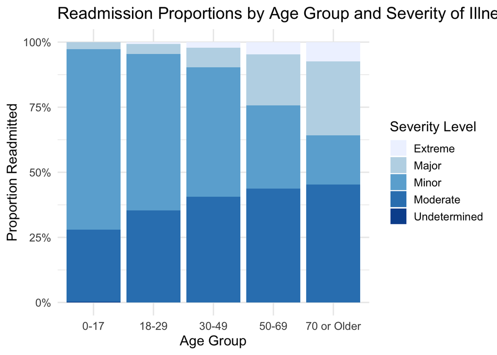

```r
# ----------------------------
# 8. Visual 1: Readmission Rate by Age & Severity
# ----------------------------
ggplot(readmit_data, aes(x = Age.Group, fill = APR.Severity.of.Illness.Description)) +
  geom_bar(position = "fill") +
  scale_y_continuous(labels = percent_format()) +
  labs(
    title = "Readmission Proportions by Age Group and Severity of Illness",
    x = "Age Group",
    y = "Proportion Readmitted",
    fill = "Severity Level"
  ) +
  theme_minimal(base_size = 14) +
  scale_fill_brewer(palette = "Blues")
```

[figure not shown]

```r
# ----------------------------
# 9. Visual 2: Readmission Rate by Payer
# ----------------------------
readmission_by_payer <- readmit_data %>%
  group_by(Payment.Typology.1) %>%
  summarise(Readmission_Rate = mean(Readmission == "Yes")) %>%
  arrange(Readmission_Rate)

ggplot(readmission_by_payer, aes(x = reorder(Payment.Typology.1, Readmission_Rate), y = Readmission_Rate)) +
  geom_col(fill = "#0066CC") +
  geom_text(aes(label = percent(Readmission_Rate, accuracy = 0.1)), vjust = -0.3, size = 4) +
  labs(
    title = "Readmission Risk by Payer Type",
    x = "Payer Type",
    y = "Readmission Rate"
  ) +
  theme_minimal(base_size = 14)
```

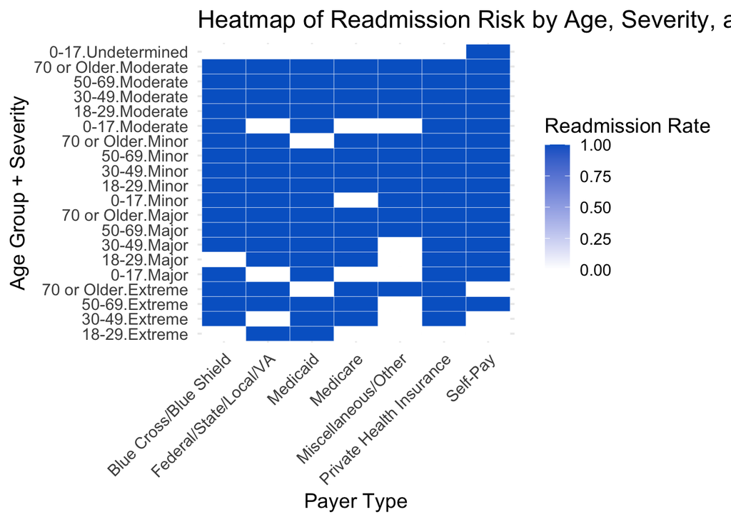

```r
# ----------------------------
# 10. Visual 3: Heatmap by Age, Severity, and Payer
# ----------------------------
readmission_heatmap <- readmit_data %>%
  group_by(Age.Group, APR.Severity.of.Illness.Description, Payment.Typology.1) %>%
  summarise(Readmission_Rate = mean(Readmission == "Yes")) %>%
  ungroup()

heatmap_data <- dcast(
  readmission_heatmap,
  Age.Group + APR.Severity.of.Illness.Description ~ Payment.Typology.1,
  value.var = "Readmission_Rate",
  fill = 0
)

heatmap_long <- melt(heatmap_data, id.vars = c("Age.Group", "APR.Severity.of.Illness.Description"))

ggplot(heatmap_long, aes(x = variable, y = interaction(Age.Group, APR.Severity.of.Illness.Description), fill = value)) +
  geom_tile(color = "white") +
  scale_fill_gradient(low = "white", high = "#0066CC", name = "Readmission Rate") +
  labs(
    title = "Heatmap of Readmission Risk by Age, Severity, and Payer",
    x = "Payer Type",
    y = "Age Group + Severity"
  ) +
  theme_minimal(base_size = 14) +
  theme(axis.text.x = element_text(angle = 45, hjust = 1))
```

```r
# ----------------------------
# 11. Summary Table
# ----------------------------
readmission_summary <- readmit_data %>%
  group_by(Age.Group, APR.Severity.of.Illness.Description, Payment.Typology.1) %>%
  summarise(Readmission_Rate = mean(Readmission == "Yes")) %>%
  arrange(Readmission_Rate)

readmission_summary %>%
  kable() %>%
  kable_styling(full_width = FALSE)
```

| Age.Group | APR.Severity.of.Illness.Description | Payment.Typology.1 | Readmission_Rate |
| --- | --- | --- | --- |
| 0-17 | Major | Blue Cross/Blue Shield | 1 |
| 0-17 | Major | Medicaid | 1 |
| 0-17 | Major | Private Health Insurance | 1 |
| 0-17 | Major | Self-Pay | 1 |
| 0-17 | Minor | Blue Cross/Blue Shield | 1 |
| 0-17 | Minor | Federal/State/Local/VA | 1 |
| 0-17 | Minor | Medicaid | 1 |
| 0-17 | Minor | Miscellaneous/Other | 1 |
| 0-17 | Minor | Private Health Insurance | 1 |
| 0-17 | Minor | Self-Pay | 1 |
| 0-17 | Moderate | Blue Cross/Blue Shield | 1 |
| 0-17 | Moderate | Medicaid | 1 |
| 0-17 | Moderate | Private Health Insurance | 1 |
| 0-17 | Moderate | Self-Pay | 1 |
| 0-17 | Undetermined | Self-Pay | 1 |
| 18-29 | Extreme | Federal/State/Local/VA | 1 |
| 18-29 | Extreme | Medicaid | 1 |
| 18-29 | Major | Federal/State/Local/VA | 1 |
| 18-29 | Major | Medicaid | 1 |
| 18-29 | Major | Medicare | 1 |
| 18-29 | Major | Private Health Insurance | 1 |
| 18-29 | Major | Self-Pay | 1 |
| 18-29 | Minor | Blue Cross/Blue Shield | 1 |
| 18-29 | Minor | Federal/State/Local/VA | 1 |
| 18-29 | Minor | Medicaid | 1 |
| 18-29 | Minor | Medicare | 1 |
| 18-29 | Minor | Miscellaneous/Other | 1 |
| 18-29 | Minor | Private Health Insurance | 1 |
| 18-29 | Minor | Self-Pay | 1 |
| 18-29 | Moderate | Blue Cross/Blue Shield | 1 |

[output cut: 82 more lines]

## 3.4 SMART Question 4

**Which factors predict in-hospital mortality, and how accurately can we classify high-risk patients?**

```r
# --------------------------------------------------
# SMART Question 4:
# Which factors predict in-hospital mortality, and
# how accurately can we classify high-risk patients?

#Goal: The goal was to find out which factors increase a patient’s chance of dying in the hospital and how accurately those high-risk patients can be identified.
# -------------------------------------------------
library(dplyr)
library(ggplot2)
library(caret)
library(pROC)


set.seed(123)

# 1. Create binary outcome: 1 = died in hospital, 0 = survived
clean_data$Mortality <- ifelse(clean_data$Patient.Disposition == "Expired", 1L, 0L)
#2 missing values
q4_data <- clean_data %>%
  filter(
    !is.na(APR.Risk.of.Mortality),
    !is.na(APR.Severity.of.Illness.Description),
    APR.Risk.of.Mortality != "Undetermined",
    APR.Severity.of.Illness.Description != "Undetermined",
    !is.na(Length.of.Stay)
  ) %>%
  select(
    Mortality,
    Age.Group,
    Type.of.Admission,
    Emergency.Department.Indicator,
    APR.Severity.of.Illness.Description,
    APR.Risk.of.Mortality,
    Length.of.Stay
  )

# 3. Set variable types

q4_data$Mortality      <- as.integer(q4_data$Mortality)
q4_data$MortalityClass <- factor(q4_data$Mortality,
                                 levels = c(0, 1),
                                 labels = c("Survived", "Died"))

q4_data$Age.Group                      <- droplevels(as.factor(q4_data$Age.Group))
q4_data$Type.of.Admission              <- droplevels(as.factor(q4_data$Type.of.Admission))
q4_data$Emergency.Department.Indicator <- droplevels(as.factor(q4_data$Emergency.Department.Indicator))
q4_data$APR.Severity.of.Illness.Description <- droplevels(as.factor(q4_data$APR.Severity.of.Illness.Description))
q4_data$APR.Risk.of.Mortality          <- droplevels(as.factor(q4_data$APR.Risk.of.Mortality))
q4_data$Length.of.Stay                 <- as.numeric(q4_data$Length.of.Stay)


# 4. Train/Test split

index_q4 <- createDataPartition(q4_data$MortalityClass, p = 0.7, list = FALSE)
train_q4 <- q4_data[index_q4, ]
test_q4  <- q4_data[-index_q4, ]

# 5. Logistic regression model

logit_q4 <- glm(
  Mortality ~ Age.Group +
    Type.of.Admission +
    Emergency.Department.Indicator +
    APR.Severity.of.Illness.Description +
    APR.Risk.of.Mortality +
    Length.of.Stay,
  data   = train_q4,
  family = binomial
)

summary(logit_q4)
```

```
##
## Call:
## glm(formula = Mortality ~ Age.Group + Type.of.Admission + Emergency.Department.Indicator +
##     APR.Severity.of.Illness.Description + APR.Risk.of.Mortality +
##     Length.of.Stay, family = binomial, data = train_q4)
##
## Coefficients:
##                                               Estimate Std. Error z value
## (Intercept)                                  -13.20469 1956.47490  -0.007
## Age.Group18-29                                12.78394 1956.47484   0.007
## Age.Group30-49                                13.35110 1956.47465   0.007
## Age.Group50-69                                13.94648 1956.47464   0.007
## Age.Group70 or Older                          13.73157 1956.47464   0.007
## Type.of.AdmissionEmergency                     0.22813    0.89292   0.255
## Type.of.AdmissionNewborn                       1.34597 2006.94633   0.001
## Type.of.AdmissionNot Available               -15.35981 6522.63867  -0.002
## Type.of.AdmissionUrgent                        1.59924    1.02830   1.555
## Emergency.Department.IndicatorY               -1.22200    0.27655  -4.419
## APR.Severity.of.Illness.DescriptionMajor      -1.65632    0.30441  -5.441
## APR.Severity.of.Illness.DescriptionMinor      -2.73707    0.78812  -3.473
## APR.Severity.of.Illness.DescriptionModerate   -2.77594    0.46107  -6.021
## APR.Risk.of.MortalityMajor                    -0.61791    0.30094  -2.053
## APR.Risk.of.MortalityMinor                    -3.96214    0.94559  -4.190
## APR.Risk.of.MortalityModerate                 -1.47284    0.46480  -3.169
## Length.of.Stay                                -0.07917    0.02166  -3.656
##                                             Pr(>|z|)
## (Intercept)                                 0.994615
## Age.Group18-29                              0.994787
## Age.Group30-49                              0.994555
## Age.Group50-69                              0.994312
## Age.Group70 or Older                        0.994400
## Type.of.AdmissionEmergency                  0.798345
## Type.of.AdmissionNewborn                    0.999465
## Type.of.AdmissionNot Available              0.998121
## Type.of.AdmissionUrgent                     0.119893
## Emergency.Department.IndicatorY             9.93e-06 ***
## APR.Severity.of.Illness.DescriptionMajor    5.30e-08 ***
## APR.Severity.of.Illness.DescriptionMinor    0.000515 ***
## APR.Severity.of.Illness.DescriptionModerate 1.74e-09 ***
## APR.Risk.of.MortalityMajor                  0.040049 *
## APR.Risk.of.MortalityMinor                  2.79e-05 ***
## APR.Risk.of.MortalityModerate               0.001531 **
## Length.of.Stay                              0.000256 ***
## ---
## Signif. codes:  0 '***' 0.001 '**' 0.01 '*' 0.05 '.' 0.1 ' ' 1
##
## (Dispersion parameter for binomial family taken to be 1)
##
##     Null deviance: 1072.30  on 4835  degrees of freedom
## Residual deviance:  680.75  on 4819  degrees of freedom
## AIC: 714.75
##
## Number of Fisher Scoring iterations: 17
```

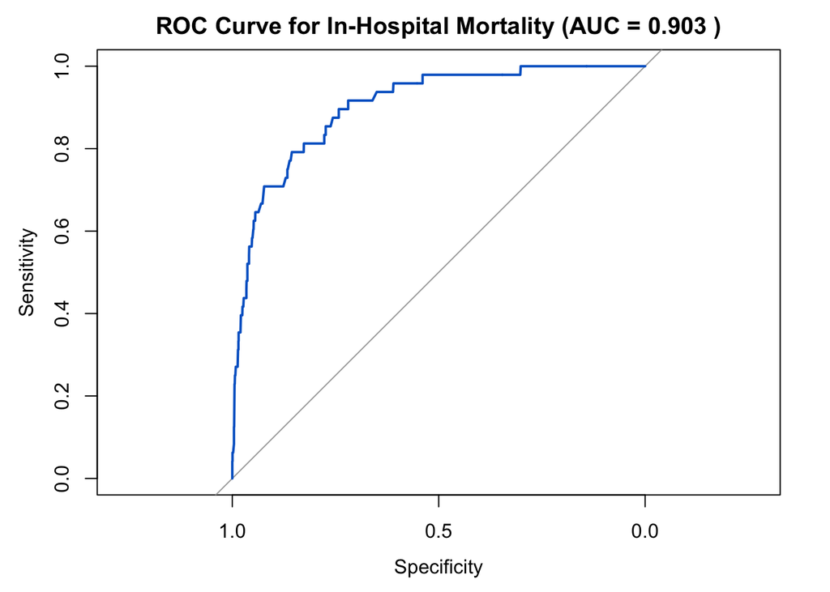

```r
# 6. Predicted probabilities on TEST set

pred_prob <- predict(logit_q4, newdata = test_q4, type = "response")

# 7. ROC curve and AUC

roc_q4 <- roc(test_q4$Mortality, pred_prob)
auc_q4 <- auc(roc_q4)

plot(roc_q4,
     col  = "#0066CC",
     lwd  = 2,
     main = paste("ROC Curve for In-Hospital Mortality (AUC =",
                  round(auc_q4, 3), ")"))
```

```r
# 8. Classify "high-risk" patients at cutoff = 0.10

cutoff <- 0.10
pred_class_num <- ifelse(pred_prob >= cutoff, 1L, 0L)
pred_class_fac <- factor(pred_class_num,
                         levels = c(0, 1),
                         labels = c("Survived", "Died"))

# Confusion matrix on test set
conf_mat_q4 <- confusionMatrix(
  pred_class_fac,
  test_q4$MortalityClass,
  positive = "Died"
)

conf_mat_q4
```

```
## Confusion Matrix and Statistics
##
##           Reference
## Prediction Survived Died
##   Survived     1942   22
##   Died           82   26
##
##                Accuracy : 0.9498
##                  95% CI : (0.9395, 0.9588)
##     No Information Rate : 0.9768
##     P-Value [Acc > NIR] : 1
##
##                   Kappa : 0.3112
##
##  Mcnemar's Test P-Value : 7.233e-09
##
##             Sensitivity : 0.54167
##             Specificity : 0.95949
##          Pos Pred Value : 0.24074
##          Neg Pred Value : 0.98880
##              Prevalence : 0.02317
##          Detection Rate : 0.01255
##    Detection Prevalence : 0.05212
##       Balanced Accuracy : 0.75058
##
##        'Positive' Class : Died
##
```

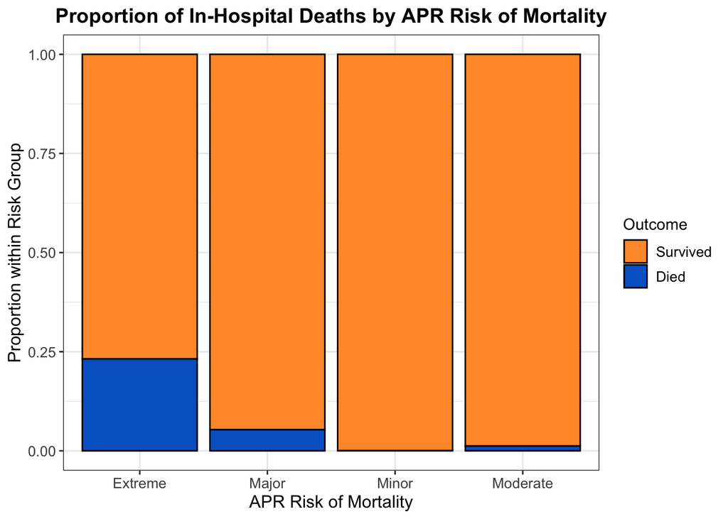

```r
# Extract key metrics
accuracy    <- conf_mat_q4$overall["Accuracy"]
sensitivity <- conf_mat_q4$byClass["Sensitivity"]
specificity <- conf_mat_q4$byClass["Specificity"]
ppv         <- conf_mat_q4$byClass["Pos Pred Value"]
npv         <- conf_mat_q4$byClass["Neg Pred Value"]

# 9. Visualization: Mortality by APR Risk

ggplot(train_q4,
       aes(x = APR.Risk.of.Mortality,
           fill = MortalityClass)) +
  geom_bar(position = "fill", color = "black") +
  scale_fill_manual(values = c("Survived" = "#FF9933",
                               "Died"      = "#0066CC")) +
  labs(
    title = "Proportion of In-Hospital Deaths by APR Risk of Mortality",
    x     = "APR Risk of Mortality",
    y     = "Proportion within Risk Group",
    fill  = "Outcome"
  ) +
  theme_bw() +
  theme(
    plot.title   = element_text(hjust = 0.5, face = "bold", size = 14),
    axis.title   = element_text(size = 12),
    axis.text    = element_text(size = 10),
    legend.title = element_text(size = 11),
    legend.text  = element_text(size = 10),
    legend.position = "right"
  )
```

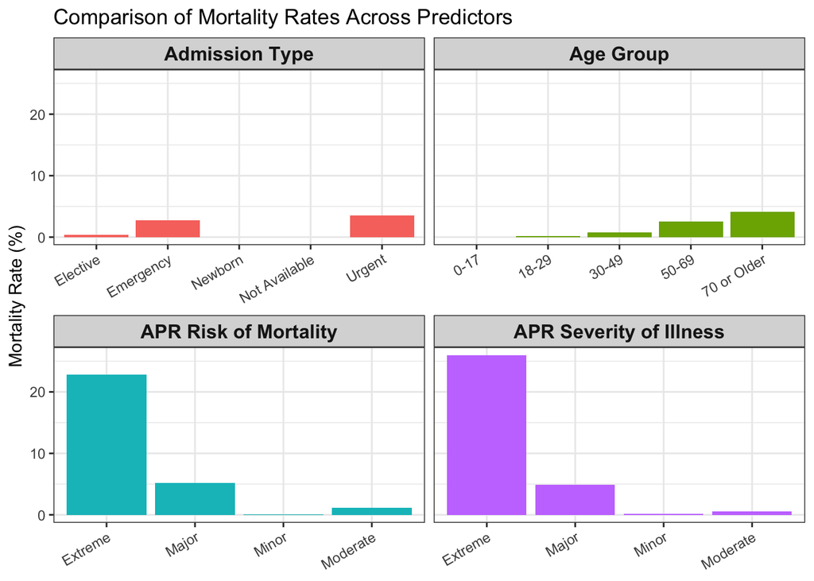

```r
# 10. Calculate mortality rate for each category of each predictor

mortality_summary <- bind_rows(
  q4_data %>%
    group_by(APR.Risk.of.Mortality) %>%
    summarise(mortality_rate = mean(Mortality)) %>%
    mutate(Factor = "APR Risk of Mortality",
           Category = APR.Risk.of.Mortality),

  q4_data %>%
    group_by(APR.Severity.of.Illness.Description) %>%
    summarise(mortality_rate = mean(Mortality)) %>%
    mutate(Factor = "APR Severity of Illness",
           Category = APR.Severity.of.Illness.Description),

  q4_data %>%
    group_by(Type.of.Admission) %>%
    summarise(mortality_rate = mean(Mortality)) %>%
    mutate(Factor = "Admission Type",
           Category = Type.of.Admission),

  q4_data %>%
    group_by(Age.Group) %>%
    summarise(mortality_rate = mean(Mortality)) %>%
    mutate(Factor = "Age Group",
           Category = Age.Group)
)
mortality_summary$Category <- as.factor(mortality_summary$Category)

# one small chart per factor
ggplot(mortality_summary,
       aes(x = Category, y = mortality_rate * 100, fill = Factor)) +
  geom_col(show.legend = FALSE) +
  facet_wrap(~ Factor, scales = "free_x") +
  labs(
    title = "Comparison of Mortality Rates Across Predictors",
    x = NULL,
    y = "Mortality Rate (%)"
  ) +
  theme_bw() +
  theme(
    strip.text = element_text(face = "bold", size = 12),
    axis.text.x = element_text(angle = 30, hjust = 1)
  )
```

```r
# 11. summary

cat("\n--- SMART Question 4 Summary ---\n")
```

```
##
## --- SMART Question 4 Summary ---
```

```r
cat("AUC:", round(auc_q4, 3), "\n")
```

```
## AUC: 0.903
```

```r
cat("Accuracy:", round(accuracy, 3), "\n")
```

```
## Accuracy: 0.95
```

```r
cat("Sensitivity:", round(sensitivity, 3), "\n")
```

```
## Sensitivity: 0.542
```

```r
cat("Specificity:", round(specificity, 3), "\n")
```

```
## Specificity: 0.959
```

```r
cat("PPV:", round(ppv, 3), "\n")
```

```
## PPV: 0.241
```

```r
cat("NPV:", round(npv, 3), "\n")
```

```
## NPV: 0.989
```

# 4 Analysis

## 4.1 SMART Question1:

Our analysis found that admission type is the strongest predictor of long hospital stays. Patients admitted with an Emergency/Urgent label has much higher odds of extended stays, while insurance type played a smaller but still meaningful role. Age, gender, and severity of illness showed little predictive power in the logistic model. Random Forest highlighted similar variables but performed slightly worse overall. Logistic regression provided clearer, more interpretable results. Overall, admission-related factors, not demographics, best explain who is likely to stay in the hospital longer.

Reliability is moderate but not perfect: Logistic regression and random forest achieved ~61–62% accuracy, only slightly above baseline. Specificity is very high, meaning the models are excellent at predicting short stays. Sensitivity is low, meaning the models struggle to detect true long stays: likely because long stays are harder to predict and may depend on unobserved clinical factors. ROC curves showed AUC values in the moderate range, consistent with partial predictive ability.

Several enhancements could strengthen predictive power:

1. Include clinical detail not captured in the dataset
- Comorbidities
- Procedure type or surgical complexity
- Vital signs or lab values
- Medication use and complications
2. Use more advanced modeling approaches
- Gradient boosting (XGBoost, LightGBM)
- Elastic net logistic regression (better variable selection)
- SMOTE or balanced resampling to improve detection of long stays
3. Incorporate interaction terms
- For example: Emergency admission × high severity or Age × severity
4. Expand categorical groups
- Collapsing categories (like insurance) may hide meaningful subpatterns.
5. Use multiple years of SPARCS data
- A larger sample can improve model stability and help detect rare long-stay patterns.

## 4.2 SMART Question2:

Based on the feature importance from the Random Forest models and Across both Medicaid and Private Insurance, Length of Stay, CCSR Diagnosis, Type of Admission, and APR Severity of Illness emerge as the most influential predictors of low hospital charges, with the lowest costs consistently linked to Newborn admissions, very short (1–2 day) stays, minor illness severity, and low-complexity diagnoses.

## 4.4 SMART Question4:

Which Factors Predict In-Hospital Mortality, and How Accurately Can High-Risk Patients Be Classified?

Exploratory Data Analysis (EDA): Initial exploration of the SPARCS dataset revealed strong associations between patient characteristics and in-hospital mortality. Mortality rates were negligible among patients with “Minor” or “Moderate” APR Risk of Mortality classifications but increased sharply for those in the “Extreme” category, where approximately 25% of patients died. Similar patterns were observed for APR Severity of Illness, where greater severity corresponded with higher mortality rates. Age and admission type also influenced outcomes—patients aged 70 years and above, as well as those admitted on an emergency basis, had higher mortality proportions. These exploratory findings guided the development of a predictive model designed to quantify which variables most strongly influenced patient death during hospitalization.

Model Selection and Methodology: Given that the outcome variable, Mortality, was binary (1 = died; 0 = survived), a logistic regression model was selected for its interpretability and appropriateness for classification problems. Logistic regression also allows for estimation of odds ratios, providing a direct measure of each factor’s contribution to mortality risk.

The model incorporated the following predictors: Age Group Type of Admission Emergency Department Indicator APR Severity of Illness APR Risk of Mortality Length of Stay Before modeling, missing and “Undetermined” values were removed, and variables were correctly coded as categorical or numeric. The dataset was then split into training (70%) and testing (30%) subsets to ensure generalizable results.

# 5 Reference

New. (2025, October 8). Hospital Inpatient Discharges (SPARCS De-Identified): 2024. Ny.gov. https://health.data.ny.gov/Health/Hospital-Inpatient-Discharges-SPARCS-De-Identified/sf4k-39ay/about_data